# Data Manipulation Workshop For Honolulu AFS August 2024

S. A. Valentine and G. R. Johnson

7/3/2023

# Introduction

This workshop will cover parts of the tidyverse including `dplyr`, `readr`, `lubridate`, and `tidyr` packages. We will use various functions to manipulate and clean fisheries data, moving from messier or raw data to something that is manageable, summarized, or able to be visualized. The aim of this workshop is to teach participants basic and commonly used tidyverse functions throughout the entire data manipulation process. We recommend using the tidyverse functions over most baseR functions as tidyverse code is more widely used and user friendly as it reads more like text and you can easily add code to continue manipulating your data in `dplyr` or adding graphics in `ggplot2`. We will not cover `ggplot2`, but it can be learned as an extension of other tidyverse functions and packages.

If you are interested in learning about the tidyverse further, I recommend Hadley Wickham’s [books](https://r4ds.hadley.nz/). R for Data science goes into more detail and is easier to follow than other books and provides examples. Parts of this workshop stem from ideas in his book.

We will use two datasets for these exercises.

Fisheries Data for walk-through examples: Long Term Resource Monitoring (LTRM) element fish community assemblage data of the Upper Mississippi River System housed at the Upper Mississippi Environmental Science Center (UMESC) with the USGS.

Fisheries Data for exercises: Gillnet catches from 1930-1932 in Lake Michigan. (https://www.sciencebase.gov/catalog/item/5e9f635482cefae35a128c38)

NOTE: This document is an R Markdown document. Therefore, all text outside of “code chunks” is just text. Code is provided in code chunks only and you can only run code that is written in code chunks. Please refer to the R Markdown tutorial shared in the pre-conference materials to better understand this format.

### Readr

Readr is part of the tidyverse that allows easy import of a large variety of datasets without column name changes, no weird data conversions, and the data are read as a tibble (a type of table that is easier to manipulate with `dplyr` functions) rather than a dataframe as in baseR (which is where many of the problems of data import stem from).

NOTE: For some packages that use baseR functions, reading data must be conducted with baseR’s `read.csv()`. I found issues in the past in packages such as SIBER and MIXSIAR that required the use of baseR rather than tidyverse functions.

For examples, you can read any delimited file using the following functions:

```r
#read comma delimited files, baseR
read.csv(data)

library(readr)
#read comma delimited files
read_csv(data)
#read semicolon delimited files
read_csv2(data)
#read tab delimited files
read_tsv(data)
#read a file with any delimiter
read_delim(data)
#read fixed-width files
read_fwf(data)
#read a table with columns separated by white space
read_table(data)
```

You can write files using the following functions:

```r
#write a .csv, baseR
write.csv(data)

library(readr)
#write a .csv
write_csv(data)
#write a .csv for Excel specifically
write_excel_csv(data)
#write a tab delimited file
write_tsv(data)
```

You can add many arguments to these reading and writing functions including skip rows (sometimes metadata are at the top of the data), header included or not, adding new lines, how to denote NAs, column type (data, integer, character), etc. For example, if R reads your data columns as an incorrect type, you can specify the column type when reading in the data. Use the `col_types` function as we will see in the example of reading the fish dataset.

We will use fish community data that were collected by the Long Term Resource Monitoring element of the Upper Mississippi River Restoration Program. These data are housed by the USGS through the Upper Mississippi Environmental Sciences Center and are freely available to use. These data are a subset of the fish community sampled in 2018.

```r
library(tidyverse) #load the readr package
fish <- read_csv("./2018 LTRM data.csv", col_types = list(weight = col_double())) #change the weight column to a numeric rather than a character string
```

Quick aside: Coercion of data types

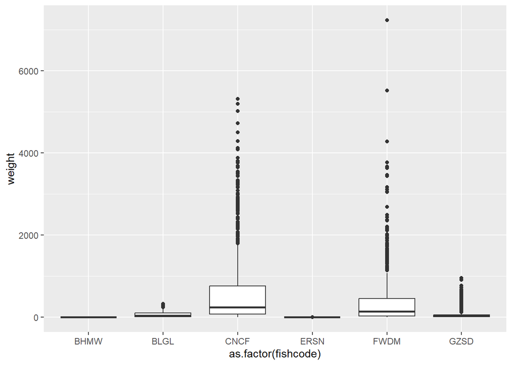

```r
#If you don't specify the column type while bringing in the data, you can coerce the columns either within a function or permanently using wrappers such as as.factor(), as.numeric()

#example in a function NOT PERMANENT CHANGE:
ggplot(fish, aes(as.factor(fishcode), weight)) +
  geom_boxplot()
```

```r
#example as permanent change:
fish$fishcode <- as.factor(fish$fishcode)

#However, if a column is read as a character and is supposed to be numeric, you need two wrappers otherwise the data will change to numeric based on ranks only. For example a character list of 0, 5, 17, 19 would be coerced to 1, 2, 3, 4 when changed to a numeric only. To preserve the 0, 5, 17, 19 when converting to numeric do the following:
fish$weight <- as.numeric(as.character(fish$weight))
```

Before we manipulate the data, it’s always a good idea to look at your data. There are several functions to look at the structure of your data and the types of variables you have. Each variable has a class (e.g. numeric, character, formula).

```r
#install dplyr
#install.packages("dplyr")

#load dplyr
library(dplyr)

dim(fish) #provides number of columns and rows
length(fish) #number of rows in dataset or column. Used for counting in functions as well
str(fish) #looks at the structure, numeric variables (num)
glimpse(fish) #similar to str, but a tidyverse function, notice that in #glimpse the factors are "dbl" meaning double which just refers to real numbers


names(fish) #provides the names of the columns
head(fish) #shows the first 6 rows of data
tail(fish) #shows the last 6 rows of data
View(fish) #opens the data in a new tab
slice(fish, 1:10) #selects the first 10 rows of data
slice(fish, 1, 10) #selects the first and 10th rows of data
```

### Unique

`unique()` is a handy baseR function. It shows you all of the individual unique variables in your dataset. This function is helpful for finding factor categories that might be duplicates because of a capitalization or spelling error or when trying to filter results and you want to know the exact factor levels and their spellings in the data.

```r
unique(fish$fishcode) #this spits out the unique factors of species in our object
```

```
## [1] BLGL FWDM GZSD ERSN CNCF BHMW
## Levels: BHMW BLGL CNCF ERSN FWDM GZSD
```

# Dplyr

Dplyr is the most commonly used tidyverse package for managing and initially summarizing data. We will discuss some of the functions. For more details on these functions as well as others not discussed, check out the dplyr webpage

Commonly used functions in `dplyr`:

*`distinct()` - selects first occurrence of data

*`rename()` - renames columns

*`select()` - select columns

*`filter()` - filters rows

*`arrange()` - sort data

*`mutate()` - adds new data/manipulations and kepps old data

*`transmute()` - adds new data/manipulations but only keeps new data

*`group_by()` - groups data

*`summarize()` - summary functions

We’ll go through each function and using the pipe as well. But let’s load the package first.

```r
#install.packages("dplyr")
library(dplyr)
```

### Distinct

`distinct()` allows you to keep only rows with a unique combination of data. For example, if you have multiple rows with the same fish ID, and only want to keep one row from each fish ID to determine your sample size of unique fish, you could use distinct.

```r
#Do we have unique IDs for all rows in the fish data?
distinct(fish, Vital_Rate_Barcode, .keep_all = TRUE)#specify the fish data, specify what column you want to have distinct values from (our ID column is called Vital_Rate_Barcode), and then .keep_all = TRUE keeps all of the other data columns rather than just the barcode column
```

```
## # A tibble: 4,804 × 87
##     ...1 site   barcode fstation sitetype stratum sdate  stime fdate ftime pool
##    <dbl> <chr>    <dbl>    <dbl>    <dbl> <chr>   <chr>  <tim> <chr> <tim> <chr>
##  1     1 <NA>  11007762        1        0 BWC-S   6/18/… 08:47 6/18… 09:02 4
##  2     2 <NA>  11007762        1        0 BWC-S   6/18/… 08:47 6/18… 09:02 4
##  3     3 <NA>  11007762        1        0 BWC-S   6/18/… 08:47 6/18… 09:02 4
##  4     4 <NA>  11007762        1        0 BWC-S   6/18/… 08:47 6/18… 09:02 4
##  5     5 <NA>  11007763        1        0 BWC-S   6/18/… 09:56 6/18… 10:11 4
##  6     6 <NA>  11007763        1        0 BWC-S   6/18/… 09:56 6/18… 10:11 4
##  7     7 <NA>  11007763        1        0 BWC-S   6/18/… 09:56 6/18… 10:11 4
##  8     8 <NA>  11007764        1        0 BWC-S   7/9/2… 07:29 7/9/… 07:44 4
##  9     9 <NA>  11007764        1        0 BWC-S   7/9/2… 07:29 7/9/… 07:44 4
## 10    10 <NA>  11007764        1        0 BWC-S   7/9/2… 07:29 7/9/… 07:44 4
## # ℹ 4,794 more rows
## # ℹ 76 more variables: lcode <chr>, gear <chr>, period <dbl>, rep <lgl>,
## #   summary <dbl>, project <chr>, effdist <dbl>, effhr <dbl>, effmin <dbl>,
## #   pwrgoal <dbl>, pwrused <dbl>, volts <dbl>, v_qf <lgl>, amps <dbl>,
## #   a_qf <lgl>, pulses <dbl>, p_qf <lgl>, dutycyc <dbl>, dc_qf <lgl>,
## #   utmzone <dbl>, utm_e <dbl>, utm_n <dbl>, gisgrid <lgl>, zone15e <dbl>,
## #   zone15n <dbl>, gpsmeth <dbl>, gpsacc <dbl>, secchi <dbl>, s_qf <dbl>, …
```

```r
#we can see this dataset has 4,804 unique rows, so 5 of our fish previously had the same barcode/ID

#The distinct function can also be used to remove duplicate rows. If you create a dataset from multiple sources that may have some overlapping data, you can remove duplicate rows by wrapping the dataframe within the distinct function
distinct(fish)
```

```
## # A tibble: 4,809 × 87
##     ...1 site   barcode fstation sitetype stratum sdate  stime fdate ftime pool
##    <dbl> <chr>    <dbl>    <dbl>    <dbl> <chr>   <chr>  <tim> <chr> <tim> <chr>
##  1     1 <NA>  11007762        1        0 BWC-S   6/18/… 08:47 6/18… 09:02 4
##  2     2 <NA>  11007762        1        0 BWC-S   6/18/… 08:47 6/18… 09:02 4
##  3     3 <NA>  11007762        1        0 BWC-S   6/18/… 08:47 6/18… 09:02 4
##  4     4 <NA>  11007762        1        0 BWC-S   6/18/… 08:47 6/18… 09:02 4
##  5     5 <NA>  11007763        1        0 BWC-S   6/18/… 09:56 6/18… 10:11 4
##  6     6 <NA>  11007763        1        0 BWC-S   6/18/… 09:56 6/18… 10:11 4
##  7     7 <NA>  11007763        1        0 BWC-S   6/18/… 09:56 6/18… 10:11 4
##  8     8 <NA>  11007764        1        0 BWC-S   7/9/2… 07:29 7/9/… 07:44 4
##  9     9 <NA>  11007764        1        0 BWC-S   7/9/2… 07:29 7/9/… 07:44 4
## 10    10 <NA>  11007764        1        0 BWC-S   7/9/2… 07:29 7/9/… 07:44 4
## # ℹ 4,799 more rows
## # ℹ 76 more variables: lcode <chr>, gear <chr>, period <dbl>, rep <lgl>,
## #   summary <dbl>, project <chr>, effdist <dbl>, effhr <dbl>, effmin <dbl>,
## #   pwrgoal <dbl>, pwrused <dbl>, volts <dbl>, v_qf <lgl>, amps <dbl>,
## #   a_qf <lgl>, pulses <dbl>, p_qf <lgl>, dutycyc <dbl>, dc_qf <lgl>,
## #   utmzone <dbl>, utm_e <dbl>, utm_n <dbl>, gisgrid <lgl>, zone15e <dbl>,
## #   zone15n <dbl>, gpsmeth <dbl>, gpsacc <dbl>, secchi <dbl>, s_qf <dbl>, …
```